# Education

Aaron Grenz & Marie Marshall

## Percentage of African Americans taking the Exam in American School System for 2013

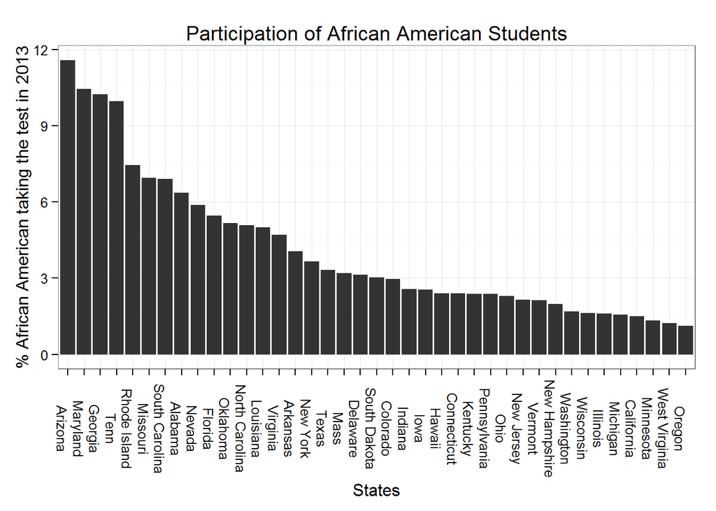

## Histogram of the Percentage of Blacks taking the Exam using GoogleVis

This graph shows there is a higher frequency of schools in the 0 to 2% range. Some schools in this range include Kansas, California, and Washington. Interestingly, Georgia, Arizona, and Maryland had the highest participation out of all the states.

[interactive chart not shown]

## US Intensity Charts with GoogleVis

This GoogleVis chart shows the percentage of African Americans passing the exam. The darker the color of a state, the higher the passing percentage.

[interactive chart not shown]

This GoogleVis chart shows the percentage of Hispanic passing the exam. The darker the color of a state, the higher the passing percentage.

[interactive chart not shown]

## Interesting Self-Created Graphs

We completed a short comparison on the pass rates of students in Washington and Oregon. Washington had a significantly higher passing rate compared to Oregon in 2013 for all students. Interestingly enough, the percentage of females who passed the exam only favored the Washington side by 0.05% in 2013.

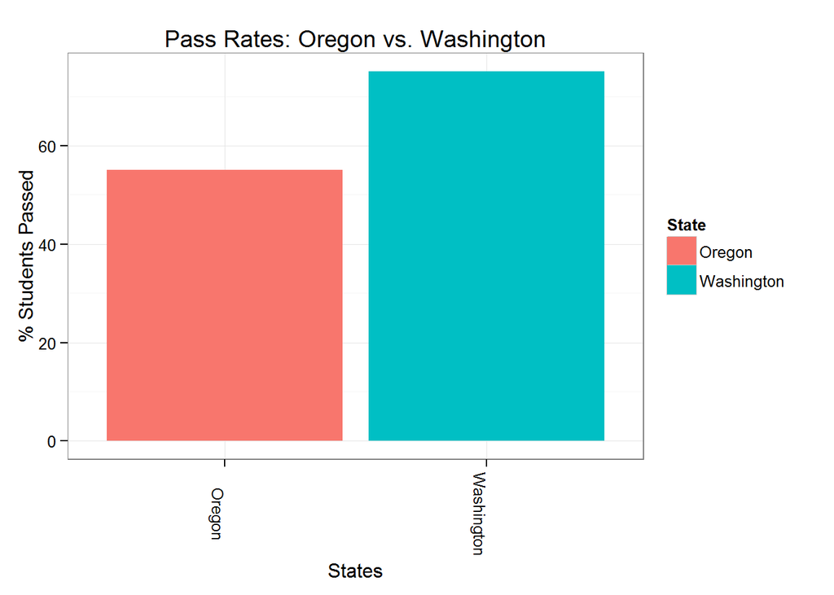

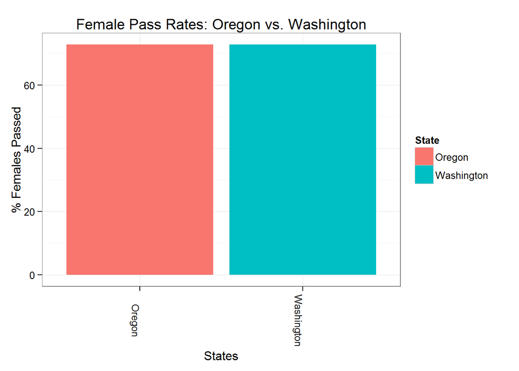